# Random Forest Classification(随机森林分类)

## 绘制交叉验证曲线

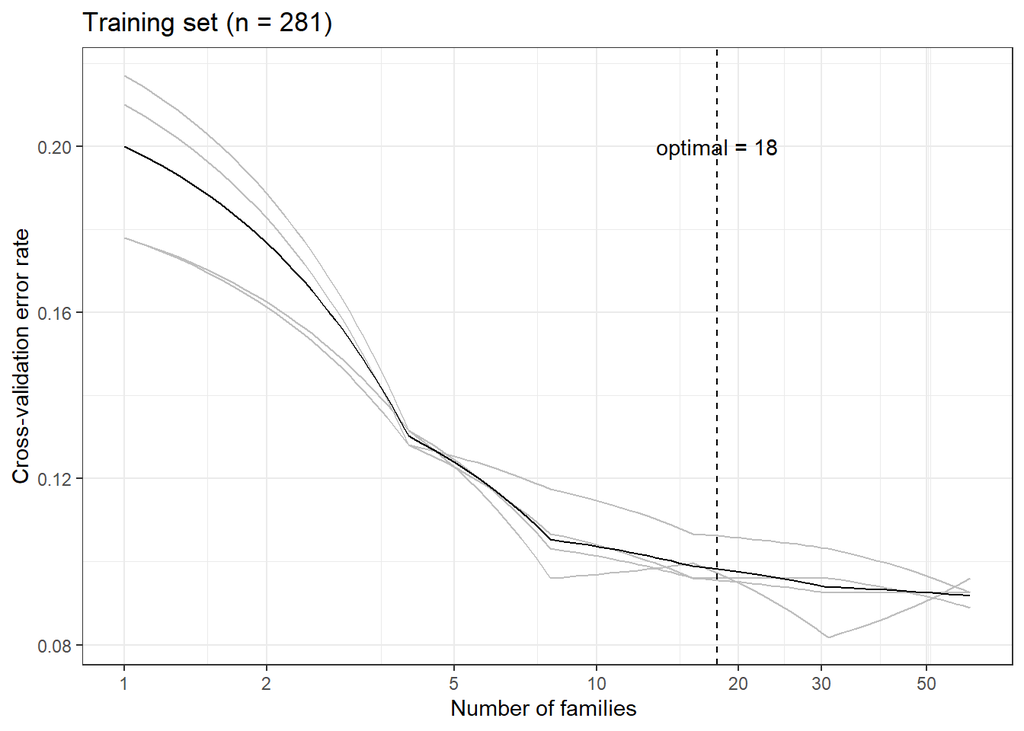

```r
# 提取x轴标签
n.var = error.cv0$num
# 提取y轴数据+标签
error.cv = error.cv0[,2:6]
colnames(error.cv) = paste('err',1:5,sep='.')
# 添加均值
err.mean = apply(error.cv,1,mean)
# 合并新的数据库，x+error+mean
allerr = data.frame(num=n.var,err.mean=err.mean,error.cv)
# number of otus selected 人为在图中观察的结果，30几乎为最低，且数量可接受
optimal = 18

# 图1：机器学习结果交叉验证图，选择Top features
# 图中 + 5条灰色拆线+1条黑色均值拆线+一条最优垂线+X轴对数变换
write.table(allerr, file = "rfcv.txt", sep = "\t", quote = F, row.names = T, col.names = T)

p = ggplot() + # 开始绘图
  geom_line(aes(x = allerr$num, y = allerr$err.1), colour = 'grey') + # 5次验证灰线
  geom_line(aes(x = allerr$num, y = allerr$err.2), colour = 'grey') +
  geom_line(aes(x = allerr$num, y = allerr$err.3), colour = 'grey') +
  geom_line(aes(x = allerr$num, y = allerr$err.4), colour = 'grey') +
  geom_line(aes(x = allerr$num, y = allerr$err.5), colour = 'grey') +
  geom_line(aes(x = allerr$num, y = allerr$err.mean), colour = 'black') + # 均值黑线
  geom_vline(xintercept = optimal, colour='black', lwd=0.36, linetype="dashed") + # 最优垂线
  coord_trans(x = "log2") + # X轴对数变换和刻度
  scale_x_continuous(breaks = c(1, 2, 5, 10, 20, 30, 50, 100, 200)) + # , max(allerr$num)
  labs(title=paste('Training set (n = ', dim(t(otu_sub))[1],')', sep = ''),
       x='Number of families ', y='Cross-validation error rate') +
  annotate("text", x = optimal, y = max(allerr$err.mean), label=paste("optimal = ", optimal, sep="")) + theme_bw()
p
```

```r
ggsave(p, file = "rfcv.pdf", width = 89, height = 59, unit = 'mm')
```

## 特征重要性可视化

```r
## 预览和保存特征贡献度
imp= as.data.frame(rf$importance)
imp = imp[order(imp$MeanDecreaseAccuracy, decreasing = T),]
head(imp,n=optimal)
```

|  | IND | TEJ | MeanDecreaseAccuracy | MeanDecreaseGini |
| --- | --- | --- | --- | --- |
| Bacteria\|Proteobacteria\|Alphaproteobacteria\|Rhizobiales\|Xanthobacteraceae | 0.018208451 | 0.042023293 | 0.024891320 | 8.391034 |
| Bacteria\|Proteobacteria\|Deltaproteobacteria\|Desulfuromonadales\|Geobacteraceae | 0.017414983 | 0.043646276 | 0.024739284 | 9.960324 |
| Bacteria\|Bacteroidetes\|Bacteroidia\|Bacteroidales\|Prolixibacteraceae | 0.005173226 | 0.038226734 | 0.014525008 | 5.126824 |
| Bacteria\|Proteobacteria\|Betaproteobacteria\|Burkholderiales\|Neisseriaceae | 0.009313993 | 0.021718075 | 0.012692554 | 5.244677 |
| Bacteria\|Firmicutes\|Clostridia\|Clostridiales\|Lachnospiraceae | 0.009183685 | 0.020443280 | 0.012394667 | 5.373660 |
| Bacteria\|Proteobacteria\|Deltaproteobacteria\|Syntrophobacterales\|Syntrophaceae | 0.010956790 | 0.015349954 | 0.012133530 | 5.800563 |
| Bacteria\|Acidobacteria\|Acidobacteria_Gp1\|Unassigned\|Unassigned | 0.009832166 | 0.016328810 | 0.011664012 | 4.803557 |
| Bacteria\|Proteobacteria\|Alphaproteobacteria\|Rhodospirillales\|Rhodospirillaceae | 0.003239731 | 0.018105910 | 0.007403179 | 3.450192 |
| Bacteria\|Actinobacteria\|Actinobacteria\|Coriobacteriales\|Coriobacteriaceae | 0.003895365 | 0.014287564 | 0.006727090 | 2.897370 |
| Bacteria\|Proteobacteria\|Betaproteobacteria\|Burkholderiales\|Burkholderiaceae | 0.004382603 | 0.012314772 | 0.006628231 | 2.340103 |

[output cut: 8 more lines]

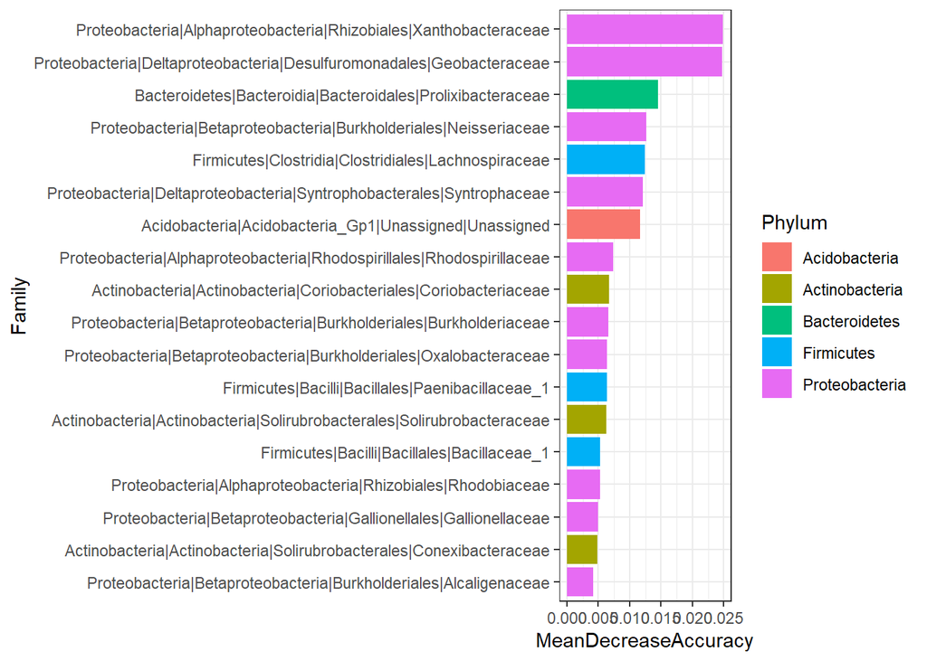

```r
write.table(imp,file = "importance.txt",quote = F,sep = '\t', row.names = T, col.names = T)
# 简单可视化，比较丑
# varImpPlot(rf, main = "Feature importance",n.var = optimal, bg = par("bg"), color = par("fg"), gcolor = par("fg"), lcolor = "gray" )

# 图2. Feature重要性：绘制条形图+门属性着色

# 读取所有feature贡献度
imp = read.table("importance.txt", header=T, row.names= 1, sep="\t")
# 分析选择top20分组效果最好，参数显示数量
imp = head(imp, n = optimal)
imp = imp[order(imp$MeanDecreaseAccuracy, decreasing = F),]
# 简化全名，去掉界
imp$Family = gsub("Bacteria\\|","",rownames(imp))
# 添加门用于着色(删除竖线后面全部)
imp$Phylum = gsub("\\|.*","",imp$Family)

# 设置顺序
imp$Family = factor(imp$Family, levels = imp$Family)

# 图2. 绘制物种类型种重要性柱状图
p = ggplot(imp, aes(x = Family, y = MeanDecreaseAccuracy, fill = Phylum)) +
  geom_bar(stat = "identity") +
  coord_flip() + theme_bw()
p
```

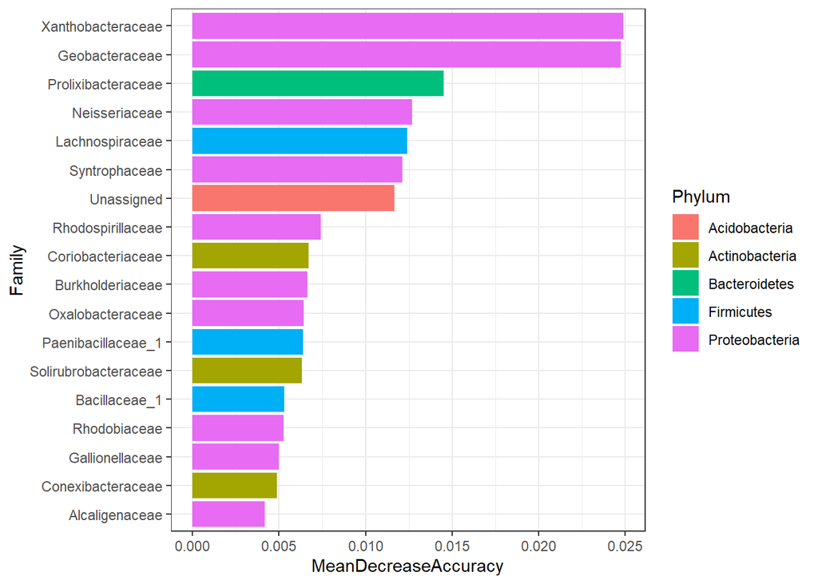

```r
ggsave(paste("top_feautre_full",".pdf", sep=""), p, width=89*2.5, height=59*2, unit='mm')
# 名称不一定唯一，需要手动修改

#  简化全名(只保留最后，有重名不可用，可选)
imp$Family = gsub(".*\\|","",imp$Family)
imp$Family = factor(imp$Family, levels = imp$Family)
p = ggplot(imp, aes(x = Family, y = MeanDecreaseAccuracy, fill = Phylum)) +
  geom_bar(stat = "identity") +
  coord_flip() + theme_bw()
p
```

```r
ggsave(paste("top_feautre",".pdf", sep=""), p, width=89*1.5, height=59*1.5, unit='mm')
```

## 测试集独立验证

如果第一地点数据量足够大，可以取出1/2到1/3进行同一地点的独立验证。方法相同。

筛选测序集样品

```r
metadata_test = subset(metadata, soiltype %in% c("H"))
summary(metadata_test)
```

```
##    groupID            genotype           soiltype         group
##  Length:282         Length:282         Length:282         IND:201
##  Class :character   Class :character   Class :character   TEJ: 81
##  Mode  :character   Mode  :character   Mode  :character
##    groupID2
##  Length:282
##  Class :character
##  Mode  :character
```

```r
idx = rownames(metadata_test) %in% colnames(table)
metadata_test = metadata_test[idx,]
otu_sub = table[,rownames(metadata_test)]

# 转置，并添加分组信息
otutab_t = as.data.frame(t(otu_sub))
otutab_t$group = metadata[rownames(otutab_t),]$group
```

基于训练集随机森林模型验证

```r
set.seed(315)
otutab.pred = predict(rf, t(otu_sub) )
pre_tab = table(observed=otutab_t[,"group"],
                predicted=otutab.pred)
pre_tab
```

```
##         predicted
## observed IND TEJ
##      IND 193   8
##      TEJ  50  31
```

可视化验证结果

```r
# 整理样本原始分组和预测分类
predict = data.frame(group = otutab_t[,"group"], predicted=otutab.pred)

# 保存预测结果表
write.table("SampleID\t", file=paste("RF_prediction_binary.txt",sep=""),append = F, quote = F, eol = "", row.names = F, col.names = F)
write.table(predict, file = "RF_prediction_binary.txt",append = T, quote = F, row.names = T, col.names = T, sep = "\t")
# 转换为数值可视化
# 预测准确标为1，错误标为0
predict$result = ifelse(predict$group == predict$predicted, 1, 0)
# IND=1, TEJ=2
predict$predict = ifelse(predict$predicted == "IND", 1, 2)
# Set sample number in each row
column = 11

IND = predict[predict$group=="IND",]$predict
length(IND)
```

```
## [1] 201
```

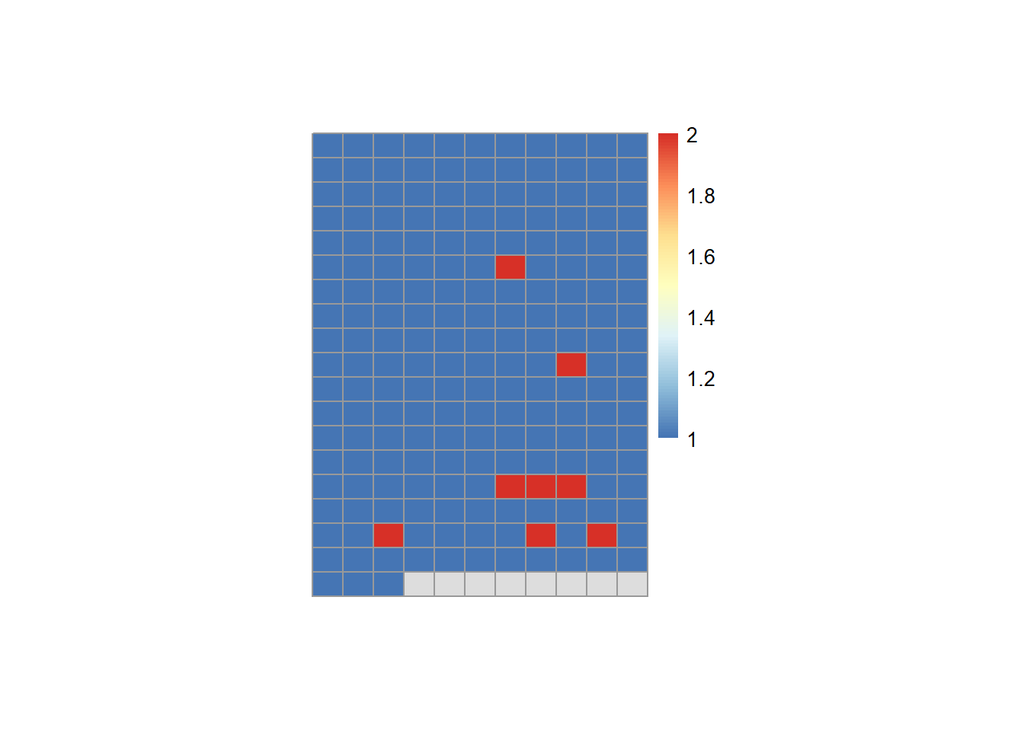

```r
row = round(length(IND)/column + 0.5)
i = column * row - length(IND)
IND = c(IND, rep(NA, i))
matrix = matrix(IND, nrow = row, ncol = column, byrow = T)
pheatmap(matrix, cluster_rows = F, cluster_cols = F, cellwidth = 15, cellheight = 12)
```

```r
pheatmap(matrix, cluster_rows = F, cluster_cols = F, cellwidth = 15, cellheight = 12,filename = "family_test_IND.pdf")

# Draw TEJ prediction result
TEJ = predict[predict$group=="TEJ",]$predict
length(TEJ)
```

```
## [1] 81
```

```r
row = round(length(TEJ)/column + 0.5)
i = column * row - length(TEJ)
TEJ = c(TEJ, rep(NA, i))
matrix = matrix(TEJ, nrow = row, ncol = column, byrow = T)
pheatmap(matrix, cluster_rows = F, cluster_cols = F, cellwidth = 15, cellheight = 12)
# 保存图片
pheatmap(matrix, cluster_rows = F, cluster_cols = F, cellwidth = 15, cellheight = 12, filename = "family_test_TEJ.pdf")
```

[output not shown]

```r
# Finished!
```

使用此脚本，请引用下文：

**Yong-Xin Liu**, Yuan Qin, **Tong Chen**, et. al. 2021. A practical guide to amplicon and metagenomic analysis of microbiome data. **Protein Cell**, 12 :315-330, doi: 10.1007/s13238-020-00724-8

测试数据发表于2019年，引文如下：

Jingying Zhang#, **Yong-Xin Liu#**, Na Zhang#, et. al. 2019. *NRT1.1B* is associated with root microbiota composition and nitrogen use in field-grown rice. **Nature Biotechnology** 37: 676-684, doi: https://doi.org/10.1038/s41587-019-0104-4

Copyright 2016-2022 Yong-Xin Liu (刘永鑫) metagenome@126.com